# Analysis

## Length

len (in characters) measured for each ipu

### Summary

mean/sd woz > robot (att)

- 7.25% increase in mean for woz compared to robot
- 8.93% increase in sd for woz compared to robot
- indicates that speakers say more and have greater variability (more dynamic) in woz condition (att. listening condition is low-stress and self-directed)

mean/sd woz < robot (ji)

- -18.17 decrease in mean for woz compared to robot
- -15.48 decrease in sd for woz compared to robot
- indicates that speakers say less and with smaller variability in the woz condition (ji condition is high-stress; possible nervousness)
- this may indicate that the woz operator better emulated a job interview scenario and led the speakers to answer more simply

```
## Percent difference: 7.24942
## Percent difference: 8.93052
```

```
## # A tibble: 2 × 7
##   Condition count   min   max median  mean    sd
##   <fct>     <int> <int> <int>  <dbl> <dbl> <dbl>
## 1 att_robot 16902     0    84      7  9.91  8.95
## 2 att_woz   23662     0    84      8 10.6   9.75
```

```
## Percent difference: -18.17226
## Percent difference: -15.4794
```

```
## # A tibble: 2 × 7
##   Condition count   min   max median  mean    sd
##   <fct>     <int> <int> <int>  <dbl> <dbl> <dbl>
## 1 ji_robot   4533     0    84     10  14.0  13.3
## 2 ji_woz     4414     0    79      8  11.5  11.3
```

### Assumptions

Normality and homogeneity of variances assumptions violated

```
## assumptions testing attentive listening
```

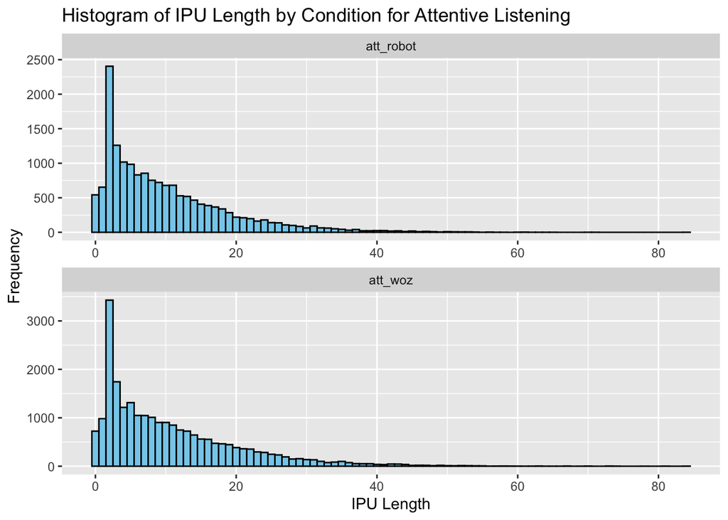

```
## Levene's Test for Homogeneity of Variance (center = median)
##          Df F value    Pr(>F)
## group     1  85.742 < 2.2e-16 ***
##       40562
## ---
## Signif. codes:  0 '***' 0.001 '**' 0.01 '*' 0.05 '.' 0.1 ' ' 1
```

```
## assumptions testing job interview
```

```
##
##  Shapiro-Wilk normality test
##
## data:  df_ji_subj$MECAB_read_len[df_ji_subj$Condition == "ji_robot"]
## W = 0.8535, p-value < 2.2e-16
```

```
##
##  Shapiro-Wilk normality test
##
## data:  df_ji_subj$MECAB_read_len[df_ji_subj$Condition == "ji_woz"]
## W = 0.83399, p-value < 2.2e-16
```

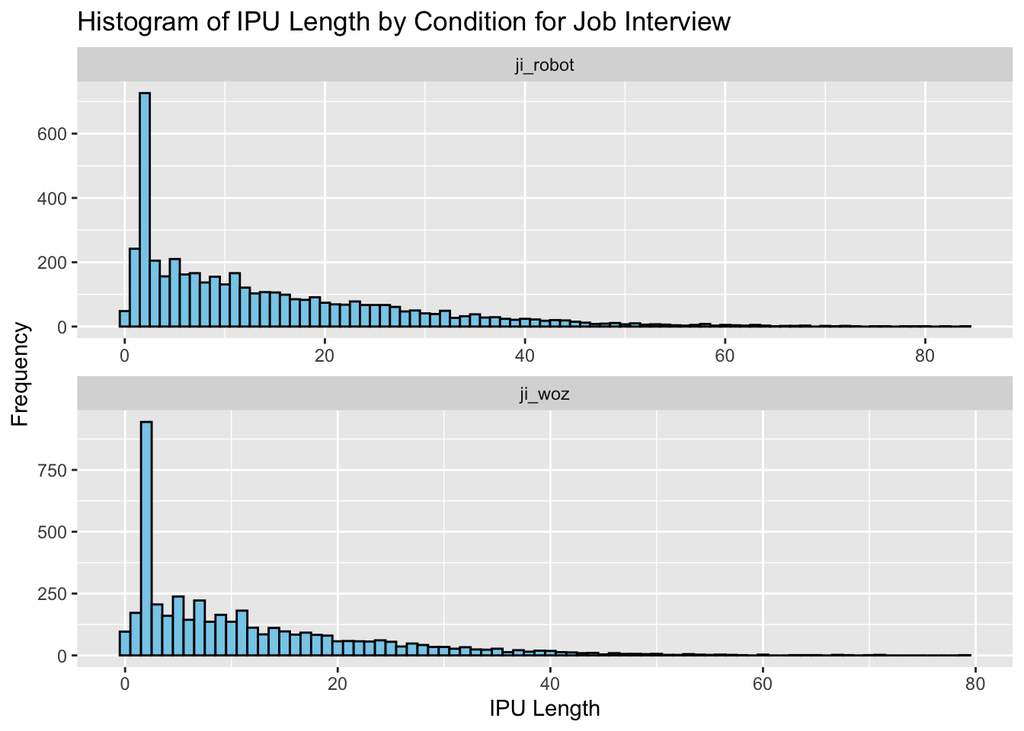

```
## Levene's Test for Homogeneity of Variance (center = median)
##         Df F value    Pr(>F)
## group    1  78.986 < 2.2e-16 ***
##       8945
## ---
## Signif. codes:  0 '***' 0.001 '**' 0.01 '*' 0.05 '.' 0.1 ' ' 1
```

### Significance Testing

- Non-parametric Wilcoxon rank-sum test
- Significant differences (p < 0.001 ***) between conditions for both attentive listening and job interview data

```
## significance testing attentive listening
```

```
##
##  Wilcoxon rank sum test with continuity correction
##
## data:  MECAB_read_len by Condition
## W = 194288855, p-value = 9.841e-07
## alternative hypothesis: true location shift is not equal to 0
```

```
## significance testing job interview
```

```
##
##  Wilcoxon rank sum test with continuity correction
##
## data:  MECAB_read_len by Condition
## W = 11027988, p-value < 2.2e-16
## alternative hypothesis: true location shift is not equal to 0
```

## Speaking Rate

measured in characters per second for each ipu

### Summary

mean/sd woz > robot (att)

- 8.66% increase in mean for woz compared to robot
- 9.06% increase in sd for woz compared to robot
- indicates that speakers speak faster and have greater variability (more dynamic) in woz condition (att. listening condition is low-stress and self-directed)

mean/sd woz > robot (ji)

- 6.60% increase in mean for woz compared to robot
- 16.53% increase in sd for woz compared to robot
- the faster speaking rate for ji may be due to nervousness during interview

```
## Percent difference: 8.664011
## Percent difference: 9.055918
```

```
## # A tibble: 2 × 7
##   Condition count   min   max median  mean    sd
##   <fct>     <int> <dbl> <dbl>  <dbl> <dbl> <dbl>
## 1 att_robot 16902     0  40.6   6.15  6.04  2.27
## 2 att_woz   23662     0  33.3   6.67  6.56  2.47
```

```
## Percent difference: 6.597587
## Percent difference: 16.53503
```

```
## # A tibble: 2 × 7
##   Condition count   min   max median  mean    sd
##   <fct>     <int> <dbl> <dbl>  <dbl> <dbl> <dbl>
## 1 ji_robot   4533     0  20.8   7.43  7.29  2.50
## 2 ji_woz     4414     0  27.8   7.67  7.77  2.91
```

### Assumptions

Normality and homogeneity of variances assumptions violated

```
## assumptions testing attentive listening
```

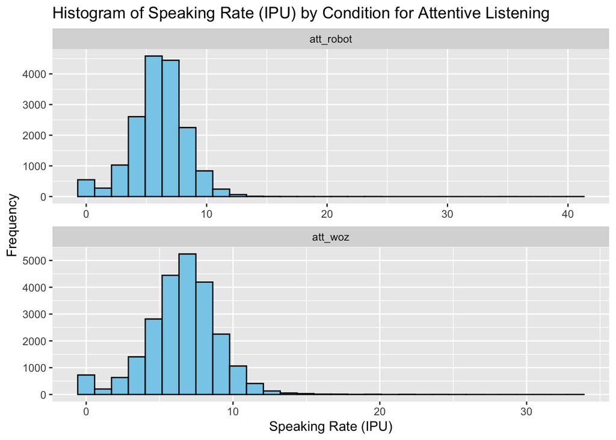

```
## Levene's Test for Homogeneity of Variance (center = median)
##          Df F value    Pr(>F)
## group     1  90.783 < 2.2e-16 ***
##       40562
## ---
## Signif. codes:  0 '***' 0.001 '**' 0.01 '*' 0.05 '.' 0.1 ' ' 1
```

```
## assumptions testing job interview
```

```
##
##  Shapiro-Wilk normality test
##
## data:  df_ji_subj$SpRateIPU[df_ji_subj$Condition == "ji_robot"]
## W = 0.98913, p-value < 2.2e-16
```

```
##
##  Shapiro-Wilk normality test
##
## data:  df_ji_subj$SpRateIPU[df_ji_subj$Condition == "ji_woz"]
## W = 0.96005, p-value < 2.2e-16
```

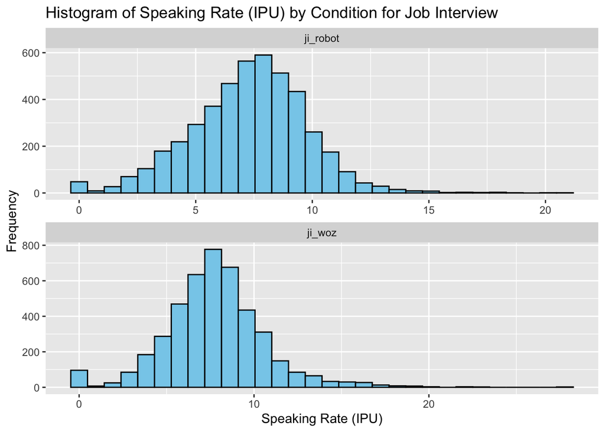

```
## Levene's Test for Homogeneity of Variance (center = median)
##         Df F value    Pr(>F)
## group    1  20.337 6.577e-06 ***
##       8945
## ---
## Signif. codes:  0 '***' 0.001 '**' 0.01 '*' 0.05 '.' 0.1 ' ' 1
```

### Significance Testing

- Non-parametric Wilcoxon rank-sum test
- Significant differences (p < 0.001 ***) between conditions for both attentive listening and job interview data

```
## significance testing attentive listening
```

```
##
##  Wilcoxon rank sum test with continuity correction
##
## data:  SpRateIPU by Condition
## W = 171793862, p-value < 2.2e-16
## alternative hypothesis: true location shift is not equal to 0
```

```
## significance testing job interview
```

```
##
##  Wilcoxon rank sum test with continuity correction
##
## data:  SpRateIPU by Condition
## W = 9170918, p-value = 8.912e-12
## alternative hypothesis: true location shift is not equal to 0
```

## Fillers (Count)

measured in count for each ipu

### Summary

count woz > robot (att)

- 11.73% increase woz compared to robot
- subjects use more fillers in woz condition
- the attentive listening scenario is mostly self-driven and low-stakes so the presence of fillers is expected
- the woz operator does a better job of creating a natural atmosphere for the subject to use fillers

count woz < robot (ji)

- -34.68% decrease woz compared to robot
- subjects use less fillers in woz condition
- job interviews demand a high level of speaking ability so it follows that interviewees would strive to reduce their filler usage
- the operator is better able to emulate a real job interview situation and lead subjects to use less fillers

```
## Percent difference: 11.72982
```

```
## # A tibble: 2 × 5
##   Condition count filler_true filler_false percFiller
##   <fct>     <int>       <int>        <int>      <dbl>
## 1 att_robot 16902        4543        12359       26.9
## 2 att_woz   23662        7106        16556       30.0
```

```
## Percent difference: -34.67927
```

```
## # A tibble: 2 × 5
##   Condition count filler_true filler_false percFiller
##   <fct>     <int>       <int>        <int>      <dbl>
## 1 ji_robot   4533        2091         2442       46.1
## 2 ji_woz     4414        1330         3084       30.1
```

### Significance Testing

- Non-parametric Chi-squared test
- Significant differences (p < 0.001 ***) between conditions for both attentive listening and job interview data

```
##
##  Pearson's Chi-squared test with Yates' continuity correction
##
## data:  df_att_subj %>% group_by(Condition) %>% summarise(filler_true = sum(HasFiller ==     TRUE), filler_false = sum(HasFiller == FALSE)) %>% ungroup() %>%     select(-1)
## X-squared = 47.721, df = 1, p-value = 4.913e-12
```

```
##
##  Pearson's Chi-squared test with Yates' continuity correction
##
## data:  df_ji_subj %>% group_by(Condition) %>% summarise(filler_true = sum(HasFiller ==     TRUE), filler_false = sum(HasFiller == FALSE)) %>% ungroup() %>%     select(-1)
## X-squared = 241.65, df = 1, p-value < 2.2e-16
```

## Fillers per second (fps)

number of fillers (per ipu) / ipu duration

### Summary

mean/sd woz > robot (att)

- 23.40% increase in mean for woz compared to robot
- 32.82% increase in sd for woz compared to robot
- speakers have a higher average fps and greater variability for fps for woz compared to robot

mean woz < robot & sd woz > robot (ji)

- -3.62 decrease in mean for woz compared to robot
- 63.98 increase in sd for woz compared to robot
- speakers decrease their average fps for the woz condition indicating that the operator might simulate a more realistic job interview

```
## Percent difference: 23.40001
## Percent difference: 32.82423
```

```
## # A tibble: 2 × 7
##   Condition count   min   max median  mean    sd
##   <fct>     <int> <dbl> <dbl>  <dbl> <dbl> <dbl>
## 1 att_robot 16902     0  22.7      0 0.259 0.665
## 2 att_woz   23662     0  23.8      0 0.320 0.883
```

```
## Percent difference: -3.621117
## Percent difference: 63.98463
```

```
## # A tibble: 2 × 7
##   Condition count   min   max median  mean    sd
##   <fct>     <int> <dbl> <dbl>  <dbl> <dbl> <dbl>
## 1 ji_robot   4533     0  20.8      0 0.479 0.954
## 2 ji_woz     4414     0  19.2      0 0.462 1.56
```

### Assumptions

```
## assumptions testing attentive listening
```

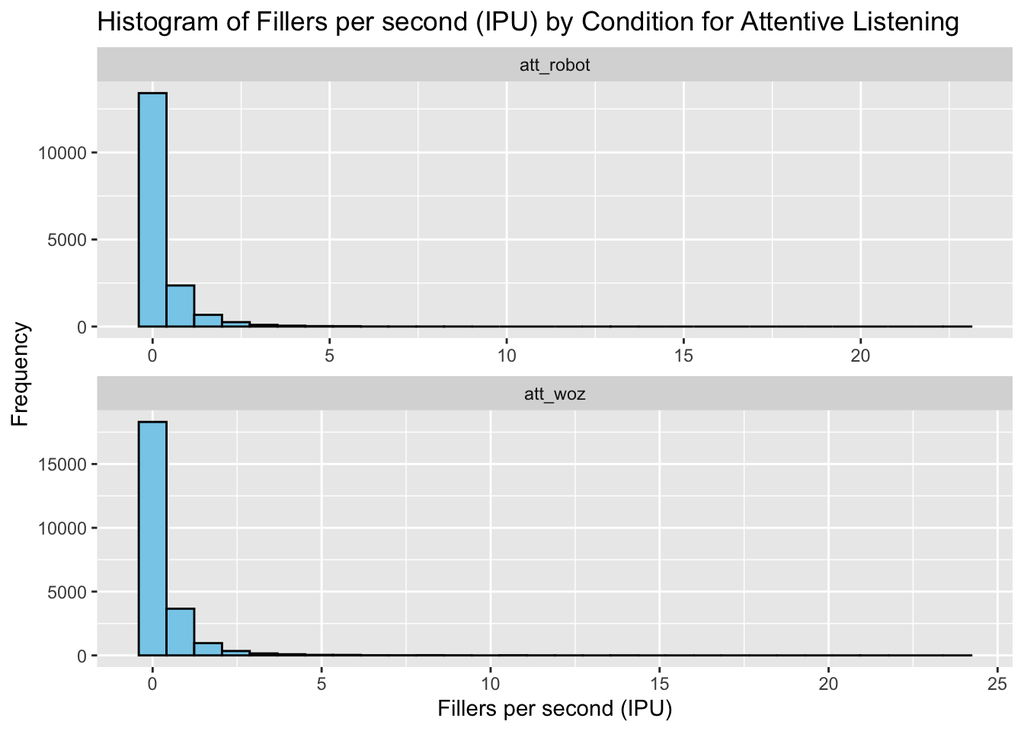

```
## Levene's Test for Homogeneity of Variance (center = median)
##          Df F value    Pr(>F)
## group     1   56.69 5.206e-14 ***
##       40562
## ---
## Signif. codes:  0 '***' 0.001 '**' 0.01 '*' 0.05 '.' 0.1 ' ' 1
```

```
## assumptions testing job interview
```

```
##
##  Shapiro-Wilk normality test
##
## data:  df_ji_subj$fps_ipu[df_ji_subj$Condition == "ji_robot"]
## W = 0.52426, p-value < 2.2e-16
```

```
##
##  Shapiro-Wilk normality test
##
## data:  df_ji_subj$fps_ipu[df_ji_subj$Condition == "ji_woz"]
## W = 0.30687, p-value < 2.2e-16
```

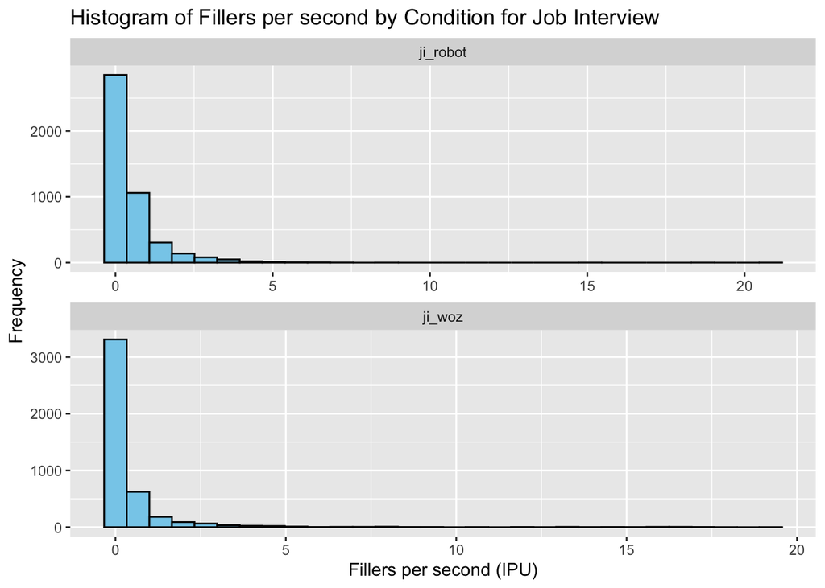

```
## Levene's Test for Homogeneity of Variance (center = median)
##         Df F value Pr(>F)
## group    1  0.4039 0.5251
##       8945
```

### Significance Testing

- Non-parametric Wilcoxon rank-sum test
- Significant differences (p < 0.001 ***) between conditions for both attentive listening and job interview data

```
## significance testing attentive listening
```

```
##
##  Wilcoxon rank sum test with continuity correction
##
## data:  fps_ipu by Condition
## W = 193369534, p-value = 1.199e-12
## alternative hypothesis: true location shift is not equal to 0
```

```
## significance testing job interview
```

```
##
##  Wilcoxon rank sum test with continuity correction
##
## data:  fps_ipu by Condition
## W = 11537216, p-value < 2.2e-16
## alternative hypothesis: true location shift is not equal to 0
```

## Backchannels (Count)

measured in count for each ipu

### Summary

count woz > robot (att)

- 10.05% increase woz compared to robot
- subjects use more backchannels in woz condition
- subjects are more active listeners with the woz operator than with the robot

count woz > robot (ji)

- 79.90% increase woz compared to robot
- subjects use more backchannels in woz condition
- subjects are more active listeners in the woz condition which means that the job interview situation might feel more realistic since it demands a focused backchannel usage

```
## Percent difference: 10.05195
```

```
## # A tibble: 2 × 5
##   Condition count backchannel_true backchannel_false percBackchannel
##   <fct>     <int>            <int>             <int>           <dbl>
## 1 att_robot 16902             1807             15095            10.7
## 2 att_woz   23662             2784             20878            11.8
```

```
## Percent difference: 79.89665
```

```
## # A tibble: 2 × 5
##   Condition count backchannel_true backchannel_false percBackchannel
##   <fct>     <int>            <int>             <int>           <dbl>
## 1 ji_robot   4533              431              4102            9.51
## 2 ji_woz     4414              755              3659           17.1
```

### Significance Testing

- Non-parametric Chi-squared test
- Significant differences (p < 0.001 ***) between conditions for both attentive listening and job interview data

```
##
##  Pearson's Chi-squared test with Yates' continuity correction
##
## data:  df_att_subj %>% group_by(Condition) %>% summarise(backchannel_true = sum(HasBackchannel ==     TRUE), backchannel_false = sum(HasBackchannel == FALSE)) %>%     ungroup() %>% select(-1)
## X-squared = 11.238, df = 1, p-value = 0.0008015
```

```
##
##  Pearson's Chi-squared test with Yates' continuity correction
##
## data:  df_ji_subj %>% group_by(Condition) %>% summarise(backchannel_true = sum(HasBackchannel ==     TRUE), backchannel_false = sum(HasBackchannel == FALSE)) %>%     ungroup() %>% select(-1)
## X-squared = 111.58, df = 1, p-value < 2.2e-16
```

## Backchannels per second (bcps)

number of backchannels (per ipu) / ipu duration

### Summary

mean/sd woz > robot (att)

- 22.57% increase in mean for woz compared to robot
- 18.42% increase in sd for woz compared to robot
- speakers have higher average bcps and greater variability for bcps for woz compared to robot
- woz operator able to elicit greater active listening (even in a predominantly subject-led dialogue) than robot

mean/sd woz > robot (ji)

- 121.03% increase in mean for woz compared to robot
- 59.87% increase in sd for woz compared to robot
- speakers have higher average bcps and greater variability for bcps for woz compared to robot
- woz operator able to elicit greater active listening for job interview (better engagement) than robot

```
## Percent difference: 22.57153
## Percent difference: 18.41599
```

```
## # A tibble: 2 × 7
##   Condition count   min   max median  mean    sd
##   <fct>     <int> <dbl> <dbl>  <dbl> <dbl> <dbl>
## 1 att_robot 16902     0  24.4      0 0.338  1.09
## 2 att_woz   23662     0  18.2      0 0.415  1.29
```

```
## Percent difference: 121.0344
## Percent difference: 59.86699
```

```
## # A tibble: 2 × 7
##   Condition count   min   max median  mean    sd
##   <fct>     <int> <dbl> <dbl>  <dbl> <dbl> <dbl>
## 1 ji_robot   4533     0  11.2      0 0.392  1.27
## 2 ji_woz     4414     0  15.2      0 0.865  2.03
```

### Assumptions

Normality and homogeneity of variances assumptions violated

```
## assumptions testing attentive listening
```

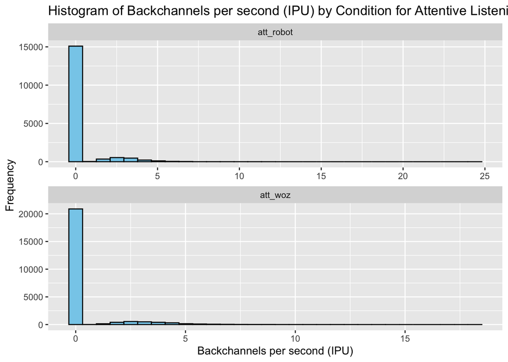

```
## Levene's Test for Homogeneity of Variance (center = median)
##          Df F value    Pr(>F)
## group     1  39.429 3.436e-10 ***
##       40562
## ---
## Signif. codes:  0 '***' 0.001 '**' 0.01 '*' 0.05 '.' 0.1 ' ' 1
```

```
## assumptions testing job interview
```

```
##
##  Shapiro-Wilk normality test
##
## data:  df_ji_subj$bcps_ipu[df_ji_subj$Condition == "ji_robot"]
## W = 0.34328, p-value < 2.2e-16
```

```
##
##  Shapiro-Wilk normality test
##
## data:  df_ji_subj$bcps_ipu[df_ji_subj$Condition == "ji_woz"]
## W = 0.48495, p-value < 2.2e-16
```

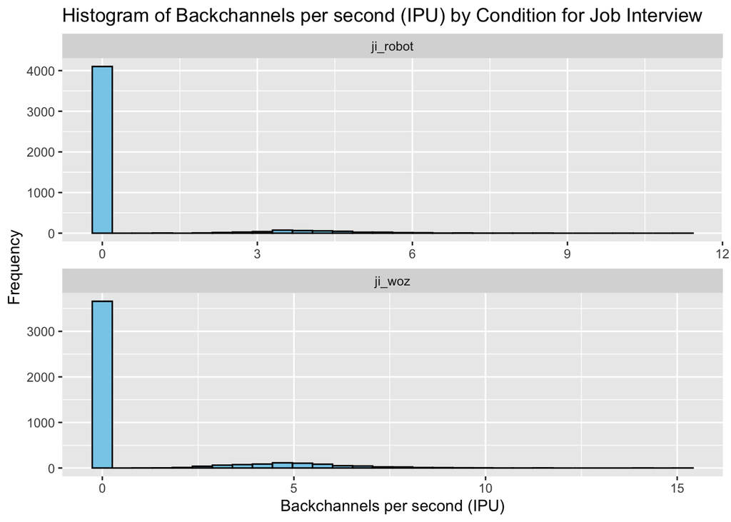

```
## Levene's Test for Homogeneity of Variance (center = median)
##         Df F value    Pr(>F)
## group    1  175.47 < 2.2e-16 ***
##       8945
## ---
## Signif. codes:  0 '***' 0.001 '**' 0.01 '*' 0.05 '.' 0.1 ' ' 1
```

### Significance Testing

- Non-parametric Wilcoxon rank-sum test
- Significant differences (p < 0.001 ***) between conditions for both attentive listening and job interview data

```
## significance testing attentive listening
```

```
##
##  Wilcoxon rank sum test with continuity correction
##
## data:  bcps_ipu by Condition
## W = 197523946, p-value = 0.000133
## alternative hypothesis: true location shift is not equal to 0
```

```
## significance testing job interview
```

```
##
##  Wilcoxon rank sum test with continuity correction
##
## data:  bcps_ipu by Condition
## W = 9186448, p-value < 2.2e-16
## alternative hypothesis: true location shift is not equal to 0
```

## Disfluency (Count)

measured in count for each ipu

### Summary

count woz < robot (att)

- -17.64% decrease woz compared to robot
- subjects use less disfluencies in woz condition
- the woz operator may be less distracting causing less disfluency errors

count woz < robot (ji)

- -10.58% decrease woz compared to robot
- subjects use less disfluencies in woz condition
- the woz operator may be less distracting causing less disfluency errors

```
## Percent difference: -17.6357
```

```
## # A tibble: 2 × 5
##   Condition count disfluency_true disfluency_false percDisfluency
##   <fct>     <int>           <int>            <int>          <dbl>
## 1 att_robot 16902            1372            15530           8.12
## 2 att_woz   23662            1582            22080           6.69
```

```
## Percent difference: -10.57766
```

```
## # A tibble: 2 × 5
##   Condition count disfluency_true disfluency_false percDisfluency
##   <fct>     <int>           <int>            <int>          <dbl>
## 1 ji_robot   4533             294             4239           6.49
## 2 ji_woz     4414             256             4158           5.80
```

### Significance Testing

- Non-parametric Chi-squared test
- Significant difference (p < 0.001 ***) between conditions for attentive listening but not for the job interview data (p > 0.05)

```
##
##  Pearson's Chi-squared test with Yates' continuity correction
##
## data:  df_att_subj %>% group_by(Condition) %>% summarise(disfluency_true = sum(HasDisfluency ==     TRUE), disfluency_false = sum(HasDisfluency == FALSE)) %>%     ungroup() %>% select(-1)
## X-squared = 29.713, df = 1, p-value = 5.009e-08
```

```
##
##  Pearson's Chi-squared test with Yates' continuity correction
##
## data:  df_ji_subj %>% group_by(Condition) %>% summarise(disfluency_true = sum(HasDisfluency ==     TRUE), disfluency_false = sum(HasDisfluency == FALSE)) %>%     ungroup() %>% select(-1)
## X-squared = 1.7074, df = 1, p-value = 0.1913
```

## Disfluencies per second (dps)

number of disfluencies (per ipu) / ipu duration

### Summary

mean woz < robot & sd woz > robot (att)

- -10.17% decrease in mean for woz compared to robot
- 17.88% increase in sd for woz compared to robot
- speakers have lower average dps but greater variability for dps for woz compared to robot
- the woz operator may be less distracting causing less disfluency errors

mean/sd woz > robot (ji)

- 33.37% increase in mean for woz compared to robot
- 38.98% increase in sd for woz compared to robot
- speakers have higher average dps and greater variability for dps for woz compared to robot

```
## Percent difference: -10.16936
## Percent difference: 17.87133
```

```
## # A tibble: 2 × 7
##   Condition count   min   max median   mean    sd
##   <fct>     <int> <dbl> <dbl>  <dbl>  <dbl> <dbl>
## 1 att_robot 16902     0  27.8      0 0.110  0.671
## 2 att_woz   23662     0  37.0      0 0.0984 0.791
```

```
## Percent difference: 33.37434
## Percent difference: 38.97522
```

```
## # A tibble: 2 × 7
##   Condition count   min   max median   mean    sd
##   <fct>     <int> <dbl> <dbl>  <dbl>  <dbl> <dbl>
## 1 ji_robot   4533     0  23.3      0 0.0735 0.634
## 2 ji_woz     4414     0  20.8      0 0.0980 0.881
```

### Assumptions

```
## assumptions testing attentive listening
```

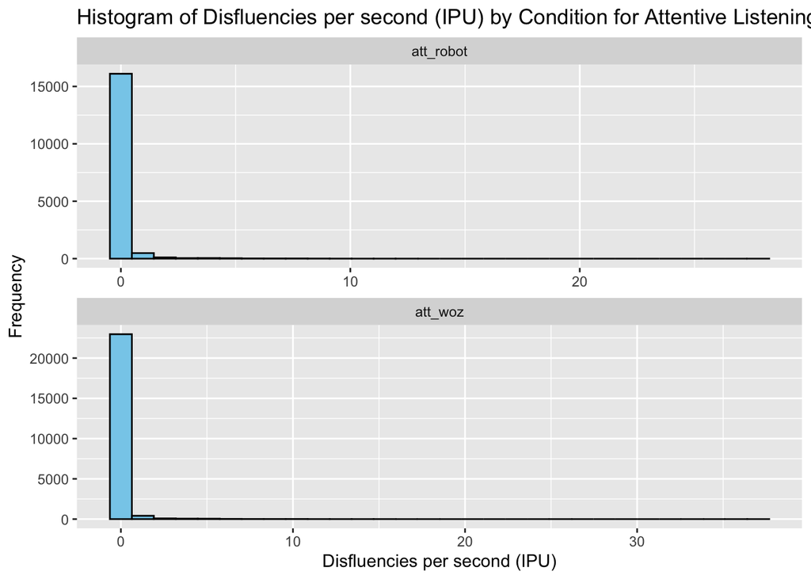

```
## Levene's Test for Homogeneity of Variance (center = median)
##          Df F value Pr(>F)
## group     1  2.2159 0.1366
##       40562
```

```
## assumptions testing job interview
```

```
##
##  Shapiro-Wilk normality test
##
## data:  df_ji_subj$dps_ipu[df_ji_subj$Condition == "ji_robot"]
## W = 0.089809, p-value < 2.2e-16
```

```
##
##  Shapiro-Wilk normality test
##
## data:  df_ji_subj$dps_ipu[df_ji_subj$Condition == "ji_woz"]
## W = 0.08602, p-value < 2.2e-16
```

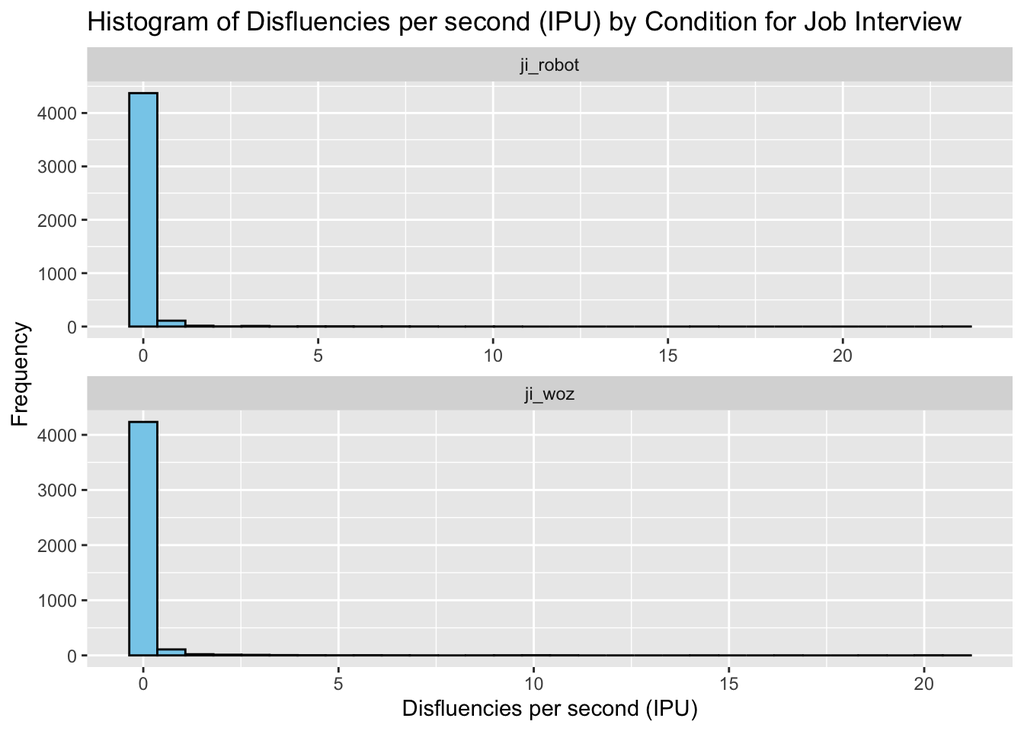

```
## Levene's Test for Homogeneity of Variance (center = median)
##         Df F value Pr(>F)
## group    1  2.2951 0.1298
##       8945
```

### Significance Testing

- Non-parametric Wilcoxon rank-sum test
- Significant difference (p < 0.001 ***) between conditions for attentive listening but not for the job interview data (p > 0.05)

```
## significance testing attentive listening
```

```
##
##  Wilcoxon rank sum test with continuity correction
##
## data:  dps_ipu by Condition
## W = 202849841, p-value = 3.743e-08
## alternative hypothesis: true location shift is not equal to 0
```

```
## significance testing job interview
```

```
##
##  Wilcoxon rank sum test with continuity correction
##
## data:  dps_ipu by Condition
## W = 10068034, p-value = 0.2103
## alternative hypothesis: true location shift is not equal to 0
```

## Laughter (Count)

measured in count for each ipu

### Summary

count woz > robot (att)

- 66.61% increase woz compared to robot
- subjects use more laughter in woz condition
- woz operators create a more humorous environment

count woz > robot (ji)

- 418.15% increase woz compared to robot
- subjects use more laughter in woz condition
- woz operators create a more humorous environment even in serious situations like a job interview (laughter and humor can be a great icebreaker, relax the situation, build rapport, show people skills, etc.)

```
## Percent difference: 66.61366
```

```
## # A tibble: 2 × 5
##   Condition count laugh_true laugh_false percLaugh
##   <fct>     <int>      <int>       <int>     <dbl>
## 1 att_robot 16902        406       16496      2.40
## 2 att_woz   23662        947       22715      4.00
```

```
## Percent difference: 418.1478
```

```
## # A tibble: 2 × 5
##   Condition count laugh_true laugh_false percLaugh
##   <fct>     <int>      <int>       <int>     <dbl>
## 1 ji_robot   4533         22        4511     0.485
## 2 ji_woz     4414        111        4303     2.51
```

### Significance Testing

- Non-parametric Chi-squared test
- Significant differences (p < 0.001 ***) between conditions for both attentive listening and job interview data

```
##
##  Pearson's Chi-squared test with Yates' continuity correction
##
## data:  df_att_subj %>% group_by(Condition) %>% summarise(laugh_true = sum(HasLaugh ==     TRUE), laugh_false = sum(HasLaugh == FALSE)) %>% ungroup() %>%     select(-1)
## X-squared = 77.798, df = 1, p-value < 2.2e-16
```

```
##
##  Pearson's Chi-squared test with Yates' continuity correction
##
## data:  df_ji_subj %>% group_by(Condition) %>% summarise(laugh_true = sum(HasLaugh ==     TRUE), laugh_false = sum(HasLaugh == FALSE)) %>% ungroup() %>%     select(-1)
## X-squared = 61.515, df = 1, p-value = 4.393e-15
```

## Laughs per second (lps)

number of laughs (per ipu) / ipu duration

### Summary

mean/sd woz > robot (att)

- 68.97% increase in mean for woz compared to robot
- 29.06% increase in sd for woz compared to robot
- speakers have higher average lps and greater variability for lps for woz compared to robot
- woz operator able to elicit greater frequency of laughs

mean/sd woz > robot (ji)

- 382.34% increase in mean for woz compared to robot
- 115.34% increase in sd for woz compared to robot
- speakers have higher average lps and greater variability for lps for woz compared to robot
- woz operator able to elicit greater frequency of laughs

```
## Percent difference: 68.97273
## Percent difference: 29.05557
```

```
## # A tibble: 2 × 7
##   Condition count   min   max median   mean    sd
##   <fct>     <int> <dbl> <dbl>  <dbl>  <dbl> <dbl>
## 1 att_robot 16902     0  11.4      0 0.0354 0.318
## 2 att_woz   23662     0  11.4      0 0.0597 0.411
```

```
## Percent difference: 382.3387
## Percent difference: 115.3369
```

```
## # A tibble: 2 × 7
##   Condition count   min   max median    mean    sd
##   <fct>     <int> <dbl> <dbl>  <dbl>   <dbl> <dbl>
## 1 ji_robot   4533     0  4.65      0 0.00713 0.132
## 2 ji_woz     4414     0  5.81      0 0.0344  0.285
```

### Assumptions

Normality and homogeneity of variances assumptions violated

```
## assumptions testing attentive listening
```

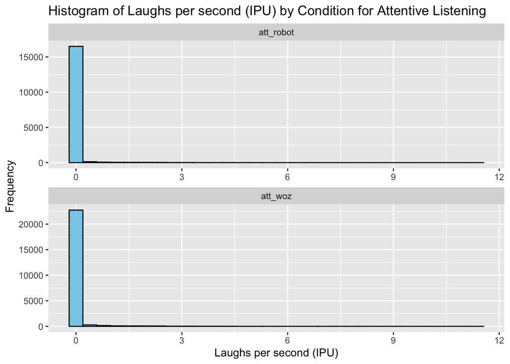

```
## Levene's Test for Homogeneity of Variance (center = median)
##          Df F value    Pr(>F)
## group     1  41.661 1.098e-10 ***
##       40562
## ---
## Signif. codes:  0 '***' 0.001 '**' 0.01 '*' 0.05 '.' 0.1 ' ' 1
```

```
## assumptions testing job interview
```

```
##
##  Shapiro-Wilk normality test
##
## data:  df_ji_subj$lps_ipu[df_ji_subj$Condition == "ji_robot"]
## W = 0.028744, p-value < 2.2e-16
```

```
##
##  Shapiro-Wilk normality test
##
## data:  df_ji_subj$lps_ipu[df_ji_subj$Condition == "ji_woz"]
## W = 0.10089, p-value < 2.2e-16
```

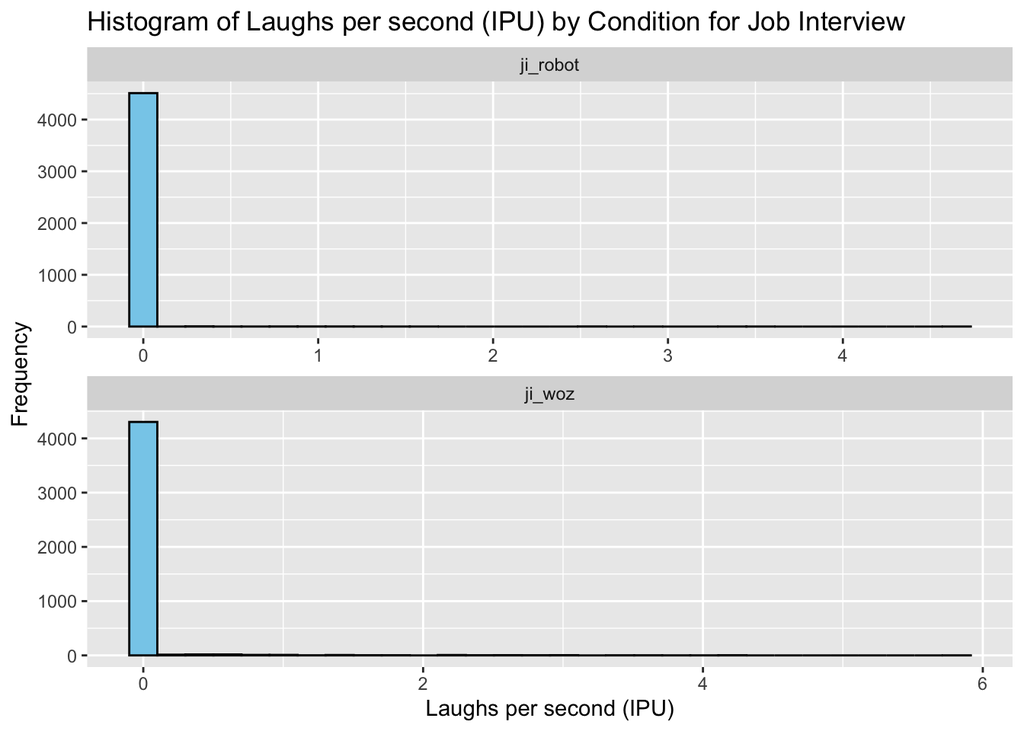

```
## Levene's Test for Homogeneity of Variance (center = median)
##         Df F value   Pr(>F)
## group    1  34.025 5.63e-09 ***
##       8945
## ---
## Signif. codes:  0 '***' 0.001 '**' 0.01 '*' 0.05 '.' 0.1 ' ' 1
```

### Significance Testing

- Non-parametric Wilcoxon rank-sum test
- Significant differences (p < 0.001 ***) between conditions for both attentive listening and job interview data

```
## significance testing attentive listening
```

```
##
##  Wilcoxon rank sum test with continuity correction
##
## data:  lps_ipu by Condition
## W = 196766134, p-value < 2.2e-16
## alternative hypothesis: true location shift is not equal to 0
```

```
## significance testing job interview
```

```
##
##  Wilcoxon rank sum test with continuity correction
##
## data:  lps_ipu by Condition
## W = 9801392, p-value = 2.257e-15
## alternative hypothesis: true location shift is not equal to 0
```